# 16S Metagenomics Training Module

16S rRNA MetagenomicsPGCV - BDML Training Module

PGCV·BDML

Philippine Genome Center Visayas

Bioinformatics and Data Management Laboratory

TRAINING MODULE

# 16S rRNA *Metagenomics*

A bioinformatics workflow for profiling microbial communities from 16S rRNA gene sequencing — concepts paired with a hands-on pipeline you can run step by step.

**VERSION 1.0 · 01 JUL 2026**

Navigation

# INTRODUCTION

This training module focuses on 16s Metagenomics Bioinformatics Workflow. Before downstream analysis, read quality control is performed as a standard procedure to assess the quality of sequencing data. Files to be analyzed are in the FASTQ format and are assessed using quality-checking tools such as FastQC. Sequence processing is then performed to characterize microbial community composition and diversity.

16S rRNA gene sequencing targets a conserved genetic marker present in bacteria and archaea, enabling taxonomic identification without the need for culturing. The 16S rRNA gene contains hypervariable regions (V1–V9) that provide species-specific signatures, allowing researchers to profile microbial communities from diverse environments such as soil, water, and gut samples. Analysis typically involves denoising sequences into Amplicon Sequence Variants (ASVs), followed by taxonomic classification against reference databases.

This module will teach the fundamental concepts of 16s metagenomics analysis using command-line interface (CLI) tools, the QIIME2 pipeline, and R for downstream statistical analysis.

The training aims to provide comprehensive instruction on amplicon-based microbial community analysis. Participants will undergo training targeting the following:

1. Learn how to navigate basic command line in Linux
2. Understand the fundamental principles of 16S rRNA gene sequencing and microbial community profiling
3. Execute an end-to-end 16S metagenomics pipeline from raw sequencing reads to quality filtering, denoising with DADA2, and taxonomic classification
4. Perform alpha and beta diversity analyses using R and Phyloseq, and interpret the results in ecological contexts
5. Predict functional profiles of microbial communities using PICRUSt2

# INTRODUCTION TO BIOINFORMATICS

Bioinformatics is defined as a data science used to analyze information both stored and processed by living organisms. It involves multiple fields such as biology, data analysis, and computer science. Its main goal is to understand biological processes through the analysis of genomic data. This field revolves greatly around sequence analysis on samples generated by sequencing instruments.

There are four categories for bioinformatics which are:

1. Classification: involved in the determination of species composition
2. Assembly: analysis on a genome’s nucleotide composition
3. Resequencing: identification of variations and mutations
4. Quantification: determination of a cell’s functional characteristics

The four previously mentioned categories fall under different methods when conducting bioinformatic analysis. An example of classification is through identifying unknown species based on their genetic material. Assembly was the focus of the Human Genome Project which paved the way for the genetic assembly for thousands of other species. Resequencing was conducted to identify changes from already recognized genomes. Focusing on the mutations and variants of DNA that have caused phenotypic changes have helped study important topics such as emerging diseases, changes in fitness, and survival rates. Quantification enabled the understanding of biological processes through gene expression.

# BIOLOGY FOR BIOINFORMATICS

The study of biology involves multiple fields such as chemistry, ecology, botany, and the like. It aims to understand living organisms and how they function, their origin, taxonomic identity, and chemical structure. Bioinformatics has proven to be a big contributor to the study of Biology as it aids in understanding the complexity involved in the multiple biological sciences.

## DNA

Deoxyribonucleic acid (DNA) is a macromolecule that contains an individual’s genetic information that is needed for its development, function, and reproduction. DNA can either be found in a nucleus or the cytoplasm of a prokaryotic cell. The composition of DNA involves two molecular strands that take the form of alternating molecules of deoxyribose and phosphate. This forms the DNA into a double helix. The strands are joined together by nucleotides, wherein the order dictates the genetic information. These nucleotides have four types: Adenine (A), Thymine (T), Guanine (G) and Cytosine (C). Base pairs are formed by these nucleotides as they are matched in the forms of “A-T,” “T-A,” “G-C,” and “C-G.”

## RNA

RNA is a similar molecule to DNA that differs in the lack of a base T and instead has a base called Uracil (U). It is single-stranded and has multiple types: mRNA, tRNA, rRNA, and others.

## Proteins

Through the genome, an organism can conduct processes such as protein production. A protein is composed of a series of amino acids. There are currently 30 identified amino acids which are represented by the letters of the alphabet. Living organisms function based on the protein interaction involved in their cells. Proteins are formed through the translation of the mRNA that partitions into three consecutive letters known as codons translated into amino acids.

# SEQUENCING

Identification of DNA composition involves DNA Sequencing stored in multiple file formats. The process begins with laboratory processes that transform DNA into a sequencing laboratory. The entire DNA sequence of an organism is found in its genome which is present in each cell. During cell division, the genome replicates into the daughter cells.

## Illumina Next Generation Sequencing

- Library Preparation - DNA or cDNA samples are used to produce a sequencing library through random fragmentation. Adapters are ligated and tagmentation is done to combine the fragmentation and ligation reactions. These samples then undergo PCR and gel purification.
- Cluster Generation - The prepared library is loaded into a flow cell containing lawns that capture the DNA fragments. The fragments undergo amplification into clusters via bridge amplification. Once cluster generation is complete, the amplified templates can then be used for sequencing.
- Sequencing - Single bases are detected as they are incorporated into DNA template strands. This will result in base-by-base sequencing.
- Data Analysis - The sequences obtained will undergo alignment with a reference genome. Once alignment has been conducted, it will enable downstream analysis. This may include detection of single nucleotide polymorphisms (SNPs), indels, read counting, or phylogenetic and metagenomic analysis.

# BASIC CODING

## Bourne-Again Shell (BASH)

BASH is an acronym for Bourne-Again Shell, a Unix shell that interprets a certain command language. It functions by analyzing and interacting with a collection of codes that will later be executed by the interface. The concept of bash is divided into two definitions: shell and scripting. The shell enables the retrieval, processing, and storage of information. Scripting is collecting these shell commands with the use of a text editor. This text editor will contain the bash commands saved as a `.sh` extension. Bash scripting is an ideal method for a workflow as it enables the execution of commands through one executable script file.

## Linux

Software manages hardware resources through an operating system when scripting. The typical operating system for handling bash scripting is Linux. Linux possesses a graphical interface with open-source software that is available to the public. It is highly reliable when conducting bioinformatic practices. One Linux distribution commonly used is Ubuntu.

## Command Line Interface

A CLI is a text-based interface for initiating commands that relay from the software to the hardware. With CLI, one can run programs, manage files, and interact with the computer. Maneuvering the CLI involves using codes that are typed, prompted, and executed.

## Navigation of Paths

When using Linux, it is important to understand a path. A path is an environment variable found in the system that aids in detecting a directory or file. There are two types of paths, namely absolute path and relative path. An absolute path is the complete path of a file containing the root element. It is composed of the directory list and a file’s specific location. On the other hand, a relative path uses a location about another location, which is typically the current directory.

Navigational Commands for a Path

| ~ | home directory |
| --- | --- |
| . | current directory |
| .. | one directory up |
| - | previous directory |

## Navigation of Commands

Handling CLI requires familiarization with basic commands. A command is formatted beginning with the command name, followed by optional arguments, and then required arguments.

Basic Linux Commands

| `pwd` | check current directory | `--help` | show manual |
| --- | --- | --- | --- |
| `cd` | change directory | `clear` | clear terminal |
| `ls` | list | `nano` | edits text (CTRL + S & CTRL + X) |
| `ls -l` | long list | `vim` | edits text (ESC, CTRL + I & :x!) |
| `tree` | show directory tree | `grep` | search instances |
| `touch` | create file | `less` | display the contents |
| `mkdir` | create directory | `sort` | sort file contents |
| `rm` | delete file | `uniq` | remove duplicate lines |
| `rmdir` | delete empty directory | `cat` | combine multiple files into one |
| `rm -r` | delete directory + files | `head` | display first few lines |
| `cp` | copy | `tail` | display last few lines |
| `mv` | move | `wc` | count newlines, words, or bytes |

Basic Linux Shortcuts

| `*tab*` | complete file name |
| --- | --- |
| `*up and down arrow*` | check previous commands |
| `* (asterisk)` | wildcard; matches one or more occurrences |
| `CTRL + C` | kill process |

# DATA HANDLING

Data is a collection of information with the ability to design and optimize it. Data can have multiple properties based on its optimization. It can be represented differently, it can be described in multiple ways, and may also not be readily accessible. Biological data is characterized into the following:

1. Data that captures prior knowledge (reference data)
2. Data obtained experimentally
3. Data produced through analysis

## Data Formats

### FASTA

- Extensions would include: `.fa, .fasta, .fna, .seq`
- A text-based file that represents the genomic sequence using the corresponding letter for each nucleotide. An additional symbol, “N” may also come up indicating that it could be any base.
- An example of a FASTA file is shown below:

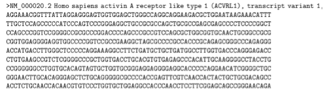

### FASTQ

- A text file that contains the sequence data from the clusters that pass filters on a flow cell.
- Composed of:
  1. Sequence Header: @ symbol followed by ID
  2. Sequence: Single-line sequence
  3. Separator: + symbol
  4. Quality Score: Phred scores encoding base call quality
- An example of a FASTQ file is shown below:

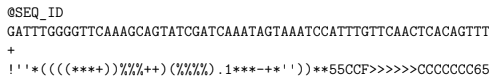

### GFF/GTF/BED

- “Interval” format that only has the coordinate positions for a region in a genome
- It contains information on the chromosomal coordinate

### SAM/BAM

- Called the sequence alignment maps
- Represent the results of aligning FASTQ file to a reference FASTA file

# 16S METAGENOMICS

## Introduction

16S metagenomics, also recognized as 16 rRNA gene sequencing, is conducted to study the microbial communities from environmental samples. Common sources would include soil, water, and gut. The gene region is amplified and is sequenced allowing analysis using bioinformatics. Through the obtained data, multiple aspects such as diversity, abundance, and relative proportions of taxa within the community may be studied.

## Metagenomics

Metagenomics is conducted to study the genetic material extracted from environmental samples without having to isolate or culture organisms individually. This has allowed studying of prokaryotes that are difficult to culture. Samples are first extracted for their DNA or RNA followed by amplification and high-throughput sequencing. Microbial communities can then be studied directly from environmental samples.

## 16S rRNA

The 16S rRNA gene is a subunit located in the ribosome of prokaryotes. It is located in all prokaryotic genomes and is highly conserved making it generally similar across multiple species. Identification and classification of these species are based on the exhibited variations. It has served as a molecular marker for studies on microbial diversity and evolution. Through its amplification followed by sequencing, comparisons of the sequences can be done to differentiate microbial communities.

# GLOSSARY

Key terms used in this module.

**16S rRNA** — Conserved ribosomal RNA gene subunit used as a marker to identify microbial taxa.

**Metagenomics** — Study of genetic material from environmental samples without culturing organisms.

**Microbial community** — Collection of microorganisms in a sample, described by composition and diversity.

**Hypervariable regions (V1–V9)** — Variable segments within 16S used to distinguish closely related taxa.

**ASV** — Amplicon Sequence Variant—exact sequence variant from denoising; finer than OTU clustering.

**OTU** — Operational Taxonomic Unit—clustered grouping of similar sequences in older workflows.

**Taxonomic classification** — Assigning sequences to ranks (phylum, genus, etc.) via reference databases.

**FASTQ** — Format storing reads, headers, and Phred-encoded quality scores.

**Paired-end reads** — Reads from both ends of a fragment (`_R1` and `_R2` per sample).

**Demultiplexing** — Separating pooled reads into per-sample files using barcodes.

**Barcode** — Short DNA tag identifying each sample in multiplexed sequencing.

**FastQC / fastp** — QC and preprocessing tools for assessing and cleaning FASTQ files.

**QIIME2** — Platform for end-to-end microbiome analysis using `.qza` artifacts and `.qzv` views.

**DADA2** — Denoising algorithm inferring exact ASVs from Illumina amplicon data.

**Denoising** — Removing sequencing errors and merging paired reads into representative sequences.

**Manifest file** — TSV mapping sample IDs to forward and reverse FASTQ file paths for QIIME2 import.

**Metadata file** — TSV describing sample groups with a `#q2:types` row for QIIME2 column types.

**`.qza` artifact** — QIIME2 native format storing analysis inputs and outputs.

**`.qzv` visualization** — QIIME2 interactive visualization viewable at view.qiime2.org.

**Cutadapt** — Tool/plugin for trimming primer and adapter sequences from reads.

**SILVA** — Reference database of ribosomal RNA sequences and taxonomy for 16S classification.

**V3–V4 region** — Commonly targeted 16S region (e.g., primers 341F/806R) for bacterial profiling.

**Feature table** — Sample-by-ASV matrix of observation counts per sequence variant.

**Representative sequences** — Unique ASV sequences corresponding to feature-table rows.

**Phylogenetic tree** — Branching diagram of evolutionary relationships among ASVs.

**Alpha diversity** — Within-sample diversity (richness, evenness)—e.g., Shannon, Faith’s PD.

**Beta diversity** — Between-sample dissimilarity—e.g., Bray-Curtis, Jaccard, UniFrac.

**Rarefaction** — Subsampling to equal read depth so diversity comparisons are not depth-biased.

**PERMANOVA** — Multivariate test (`adonis2`) for significant differences in community composition.

**PCoA / NMDS** — Ordination methods projecting community data into 2D for visualization.

**phyloseq** — R package integrating feature tables, taxonomy, trees, and metadata.

**qiime2R** — R package importing QIIME2 artifacts into a phyloseq object.

**DESeq2** — Statistical method for differential abundance between treatment groups.

**PICRUSt2** — Predicts functional gene content from 16S data via KEGG/MetaCyc pathways.

**Conda / Miniconda** — Package and environment manager for installing the QIIME2 software stack.

# THE 16S METAGENOMICS ANALYSIS WORKFLOW

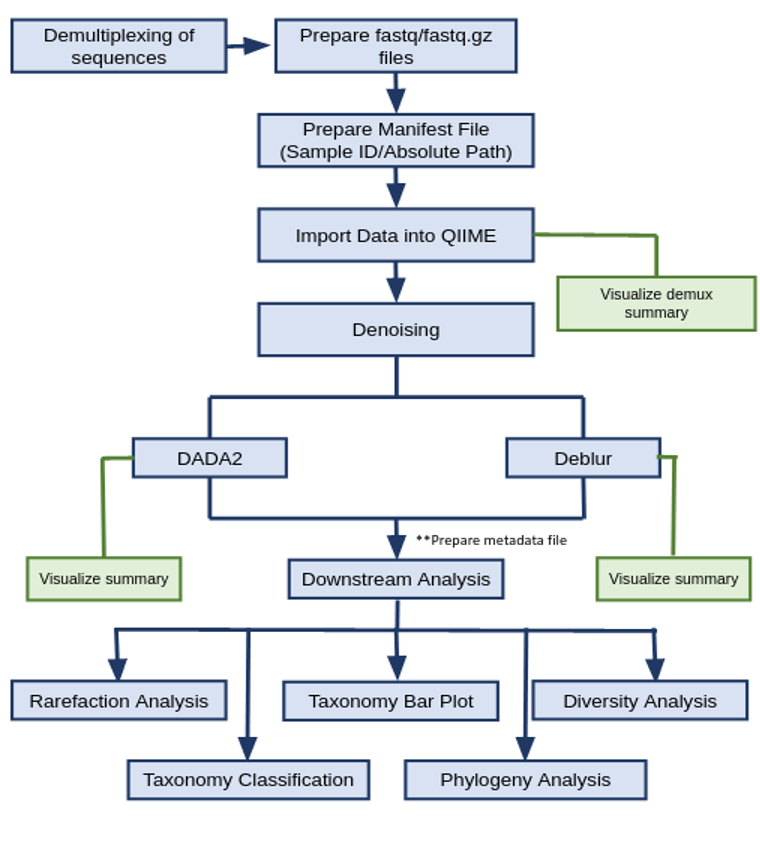

Workflow of 16S metagenomics analysis using the QIIME2 pipeline and R.

## Demultiplexing of Sequences

Sequenced samples are run together and must therefore undergo demultiplexing. It processes by utilizing barcode information that are unique sequences ligated to the genetic material of the individual samples. These barcodes allow the separate files to be sorted into sorted reads. The data will come in the form of a FASTQ file containing sequence data coming from the clusters that pass the filter on a flow cell. When a cluster passes the filter, the sequence is indicated to its corresponding FASTQ file.

## Quality Control

After demultiplexing the sequences, they must undergo a quality control step using the FastQC tool. FastQC is a program designed to spot potential problems in high-throughput sequencing datasets. It runs a set of analyses on one or more raw sequence files in `fastq.gz` or `bam` format and produces a report that summarises the results. The tool reports the basic statistics that are shown in the figure below.

[figure not shown]

GUI appplication of FastQC

## Quality Filtering and Adapter Trimming with fastp

Raw paired-end reads undergo quality control and adapter trimming using **fastp**, a fast all-in-one FASTQ preprocessing tool. The script below processes all samples in the raw FASTQ directory, applies sliding-window quality trimming, filters low-quality reads, enforces a minimum read length, and writes per-sample HTML/JSON QC reports. Run fastp before QIIME2 import.

```bash
#!/bin/bash

input_dir="${1:-fastq_raw}"
output_dir="${2:-fastq_trimmed}"
threads="${THREADS:-8}"

if [ ! -d "$input_dir" ]; then
    echo "ERROR: Input directory not found: $input_dir" >&2
    exit 1
fi

mkdir -p "$output_dir"

source ~/miniconda3/bin/activate fastp

forward_reads=( "$input_dir"/*_R1.fastq.gz )

if [ ${#forward_reads[@]} -eq 0 ]; then
    echo "ERROR: No files matching *_R1.fastq.gz found in $input_dir" >&2
    exit 1
fi

for r1 in "${forward_reads[@]}"; do
    sample=$(basename "$r1" _R1.fastq.gz)
    r2="$input_dir/${sample}_R2.fastq.gz"

    if [ ! -f "$r2" ]; then
        echo "WARNING: Missing reverse read for $sample, skipping." >&2
        continue
    fi

    echo "Processing $sample"

    fastp \
        --in1 "$r1" \
        --in2 "$r2" \
        --out1 "$output_dir/${sample}_filtered_R1.fastq.gz" \
        --out2 "$output_dir/${sample}_filtered_R2.fastq.gz" \
        --cut_right \
        --cut_right_window_size 4 \
        --cut_right_mean_quality 25 \
        --qualified_quality_phred 25 \
        --average_qual 25 \
        --length_required 120 \
        --thread "$threads" \
        --json "$output_dir/${sample}_fastp.json" \
        --html "$output_dir/${sample}_fastp.html"
done

echo "Finished. Output written to $output_dir"
```

## QIIME2 Installation

There are several steps to be taken before QIIME2 native installation. Make sure you already installed the Miniconda to provide a conda environment. Run `conda init` at the end of the installation process, to ensure that your Miniconda installation is fully installed and available for the following commands.

```bash
wget https://data.qiime2.org/distro/amplicon/qiime2-amplicon-2024.2-py38-linux-conda.yml

conda env create -n qiime --file qiime2-amplicon-2024.2-py38-linux-conda.yml
```

## Preparation of Trimmed Files for QIIME2 Sequence Importation

### Manifest File

For the importation of samples, a manifest file is first required to properly locate the data. The manifest file must contain the sample-id (file name) and absolute file path. The manifest file may be inputted manually or through the terminal with this format:

```bash
# Create manifest.tsv from trimmed paired-end FASTQ files
printf 'sample-id\tforward-absolute-filepath\treverse-absolute-filepath\n' > metadata/manifest.tsv

for forward_read in ./fastq_trimmed/*_filtered_R1.fastq.gz; do
    sample_id=$(basename "$forward_read" _filtered_R1.fastq.gz)
    reverse_read="${forward_read/_R1.fastq.gz/_R2.fastq.gz}"
    printf '%s\t%s\t%s\n' "$sample_id" "$(realpath "$forward_read")" "$(realpath "$reverse_read")" >> metadata/manifest.tsv
done
```

| sample-id | forward-absolute-filepath | reverse-absolute-filepath |
| --- | --- | --- |
| conditionA_1 | /path/to/fastq_trimmed/conditionA_1_filtered_R1.fastq.gz | /path/to/fastq_trimmed/conditionA_1_filtered_R2.fastq.gz |
| conditionA_2 | /path/to/fastq_trimmed/conditionA_2_filtered_R1.fastq.gz | /path/to/fastq_trimmed/conditionA_2_filtered_R2.fastq.gz |
| conditionA_3 | /path/to/fastq_trimmed/conditionA_3_filtered_R1.fastq.gz | /path/to/fastq_trimmed/conditionA_3_filtered_R2.fastq.gz |
| conditionB_1 | /path/to/fastq_trimmed/conditionB_1_filtered_R1.fastq.gz | /path/to/fastq_trimmed/conditionB_1_filtered_R2.fastq.gz |
| conditionB_2 | /path/to/fastq_trimmed/conditionB_2_filtered_R1.fastq.gz | /path/to/fastq_trimmed/conditionB_2_filtered_R2.fastq.gz |
| conditionB_3 | /path/to/fastq_trimmed/conditionB_3_filtered_R1.fastq.gz | /path/to/fastq_trimmed/conditionB_3_filtered_R2.fastq.gz |

*Example `manifest.tsv` — replace `/path/to/` with the actual absolute path on your system.*

### Metadata File

For further downstream analysis, a metadata file must be created containing the sample-id and other data one may want to be included. A sample format is shown below.

```bash
# Create metadata.tsv template
printf 'sample-id\tgroup1\tshort_id\n' > metadata/metadata.tsv
printf '#q2:types\tcategorical\tcategorical\n' >> metadata/metadata.tsv

for forward_read in ./fastq_trimmed/*_filtered_R1.fastq.gz; do
    sample_id=$(basename "$forward_read" _filtered_R1.fastq.gz)
    printf '%s\t\t%s\n' "$sample_id" "$sample_id" >> metadata/metadata.tsv
done

# After generating the file, open metadata.tsv and fill in the group1 column
# with your experimental group labels (e.g. "Condition A", "Condition B")
```

| sample-id | group1 | short_id |
| --- | --- | --- |
| #q2:types | categorical | categorical |
| conditionA_1 | Condition A | conditionA_1 |
| conditionA_2 | Condition A | conditionA_2 |
| conditionA_3 | Condition A | conditionA_3 |
| conditionB_1 | Condition B | conditionB_1 |
| conditionB_2 | Condition B | conditionB_2 |
| conditionB_3 | Condition B | conditionB_3 |

*Example `metadata.tsv` — the `#q2:types` row defines column types required by QIIME2. Fill in group labels to match your experimental design.*

Metadata should contain the Sample ID and the context of your samples that might either be categorical or numerical.

### Reference Files

The reference files must also be prepared based on the database of choice. This pipeline uses the **SILVA 138 / 138.2** database, pre-trimmed to the target amplicon region. The following `.qza` reference artifacts are present in the `reference/` folder:

| File | Size | Description | Used in pipeline |
| --- | --- | --- | --- |
| silva-138.2-ssu-nr99-v3v4-seqs-derep-uniq.qza | 36 MB | SILVA 138.2 SSU NR99 sequences trimmed to the V3–V4 region, dereplicated and deduplicated | ✓ |
| silva-138.2-ssu-nr99-v3v4-tax-derep-uniq.qza | 8.0 MB | Taxonomy strings for the dereplicated SILVA 138.2 V3–V4 reference sequences | ✓ |
| silva-138-99-seqs-515-806.qza | 14 MB | SILVA 138 99% NR sequences trimmed to the V4 region (primers 515–806) | — |
| silva-138-99-tax-515-806.qza | 5.3 MB | Taxonomy strings for the SILVA 138 99% NR V4 (515–806) reference sequences | — |
| ref-seqs.qza | 147 MB | Full-length reference sequences (SILVA 138, for use with classify-sklearn) | — |
| ref-tax.qza | 11 MB | Taxonomy strings for the full-length SILVA 138 reference sequences | — |

The two **SILVA 138.2 V3–V4** files (✓) are the ones used by `classify-consensus-vsearch` in this pipeline. They can be downloaded and prepared using the `q2-rescript` QIIME2 plugin:

```bash
# Download SILVA 138.2 SSU NR99 reference sequences and taxonomy
qiime rescript get-silva-data \
  --p-version '138.2' \
  --p-target 'SSURef_NR99' \
  --o-silva-sequences reference/silva-138.2-ssu-nr99-seqs.qza \
  --o-silva-taxonomy reference/silva-138.2-ssu-nr99-tax.qza

# Trim to V3-V4 region using 341F / 806R primers
qiime feature-classifier extract-reads \
  --i-sequences reference/silva-138.2-ssu-nr99-seqs.qza \
  --p-f-primer CCTACGGGNGGCWGCAG \
  --p-r-primer GACTACHVGGGTATCTAAT \
  --p-min-length 100 \
  --p-max-length 600 \
  --o-reads reference/silva-138.2-ssu-nr99-v3v4-seqs.qza

# Dereplicate sequences and taxonomy (mode: uniq)
qiime rescript dereplicate \
  --i-sequences reference/silva-138.2-ssu-nr99-v3v4-seqs.qza \
  --i-taxa reference/silva-138.2-ssu-nr99-tax.qza \
  --p-mode uniq \
  --o-dereplicated-sequences reference/silva-138.2-ssu-nr99-v3v4-seqs-derep-uniq.qza \
  --o-dereplicated-taxa reference/silva-138.2-ssu-nr99-v3v4-tax-derep-uniq.qza
```

## QIIME2 Pipeline

### Import Sequences

After quality filtering with fastp, paired-end reads are imported into QIIME2 using a **manifest file** that maps each sample ID to its forward and reverse FASTQ file paths. The manifest is generated automatically from the trimmed FASTQ directory. The resulting `paired-end-demux.qza` artifact is the entry point for all subsequent QIIME2 steps.

```bash
# Activate QIIME2 environment
source ~/miniconda3/bin/activate qiime2-2024.10

mkdir -p metadata output/qza output/exports

# Build manifest.tsv from trimmed FASTQ files
printf 'sample-id\tforward-absolute-filepath\treverse-absolute-filepath\n' > metadata/manifest.tsv

for forward_read in ./fastq_trimmed/*_filtered_R1.fastq.gz; do
    sample_id=$(basename "$forward_read" _filtered_R1.fastq.gz)
    reverse_read="${forward_read/_R1.fastq.gz/_R2.fastq.gz}"
    printf '%s\t%s\t%s\n' "$sample_id" "$(realpath "$forward_read")" "$(realpath "$reverse_read")" >> metadata/manifest.tsv
done

# Import paired-end reads into QIIME2 artifact
qiime tools import \
  --type 'SampleData[PairedEndSequencesWithQuality]' \
  --input-path ./metadata/manifest.tsv \
  --output-path ./output/qza/paired-end-demux.qza \
  --input-format PairedEndFastqManifestPhred33V2
```

### Trimming of Primers

```bash
# Remove 16S V3-V4 primers using QIIME2 CutAdapt plugin
# Forward primer: CCTACGGGNGGCWGCAG
# Reverse primer: GACTACHVGGGTATCTAAT

qiime cutadapt trim-paired \
  --i-demultiplexed-sequences "./output/qza/paired-end-demux.qza" \
  --p-cores 20 \
  --p-match-read-wildcards \
  --p-front-f CCTACGGGNGGCWGCAG \
  --p-front-r GACTACHVGGGTATCTAAT \
  --o-trimmed-sequences "./output/qza/trimmed-demux.qza" \
  --verbose

# Summarize the trimmed demux artifact
qiime demux summarize \
  --i-data output/qza/trimmed-demux.qza \
  --o-visualization output/qza/trimmed-demux.qzv
```

### DADA2 Denoising

This procedure encompasses denoising, trimming for quality, filtering sequences, and eliminating chimeric sequences. Below are the parameters used for QIIME2 DADA2 denoising. The artifact for the trimmed sequences is utilized for denoising. Truncation of sequences is still required to remove the position at which sequences decreased in quality. During sequencing, usually the 3’ end of the forward reads are sequenced in the last cycles so it might have a significant change to the sequences, thus trimming is required. This command generates two files: a `table.qza` containing ASV count data and `rep-seqs.qza` containing representative sequences for each ASV. Additionally, it provides denoising process statistics, offering insights into the quality and usability of the sequences.

```bash
# Run DADA2 paired-end denoising
# Adjust --p-trunc-len-f and --p-trunc-len-r based on your quality profile
qiime dada2 denoise-paired \
    --i-demultiplexed-seqs output/qza/trimmed-demux.qza \
    --p-trunc-len-f 250 \
    --p-trunc-len-r 240 \
    --p-max-ee-f 5 \
    --p-max-ee-r 5 \
    --p-min-overlap 12 \
    --p-n-threads 8 \
    --p-chimera-method pooled \
    --p-n-reads-learn 200000 \
    --o-table output/qza/table.qza \
    --o-representative-sequences output/qza/rep-seqs.qza \
    --o-denoising-stats output/qza/denoising-stats.qza \
    --verbose

# Tabulate denoising statistics
qiime metadata tabulate \
  --m-input-file output/qza/denoising-stats.qza \
  --o-visualization output/qza/denoising-stats.qzv
```

### Visualization of the QIIME Artifacts

QIIME2 can generate a summary and table from the .qza file to a .qzv visualization artifact. This file can then be utilized as input on https://view.qiime2.org. The command will provide a summary of the count table along with a list of representative sequences and their corresponding OTU IDs.

```bash
# Summarize feature table with sample metadata
qiime feature-table summarize \
  --i-table output/qza/table.qza \
  --o-visualization output/qza/table.qzv \
  --m-sample-metadata-file metadata/metadata.tsv

# Tabulate representative sequences
qiime feature-table tabulate-seqs \
  --i-data output/qza/rep-seqs.qza \
  --o-visualization output/qza/rep-seqs.qzv
```

### Taxonomic Classification

QIIME2 offers a taxonomy assignment tool for the representative sequences, requiring a database tailored to the specific region of interest. For this instance, the prokaryotic SILVA 138.2 V3–V4 region 16S SSU database is used as the reference for the sequences. The reference was trimmed to retain only the sequences spanning the V3–V4 region of the prokaryotic 16S SSU gene. Using consensus VSEARCH alignment at 95 percent identity, an output file is produced containing the respective taxonomies of the representative sequences. To download the database, access https://www.arb-silva.de/download/arb-files/ in Application Resource Bundle (.arb) format or use q2-rescript plug-in in QIIME2 to download the SILVA database in .qza format.

```bash
# Classify representative sequences against SILVA 138.2 V3-V4 reference
qiime feature-classifier classify-consensus-vsearch \
  --i-query output/qza/rep-seqs.qza \
  --i-reference-reads ./reference/silva-138.2-ssu-nr99-v3v4-seqs-derep-uniq.qza \
  --i-reference-taxonomy ./reference/silva-138.2-ssu-nr99-v3v4-tax-derep-uniq.qza \
  --o-classification output/qza/taxonomy.qza \
  --o-search-results output/qza/taxonomy-hits.qza \
  --p-threads 6 \
  --p-top-hits-only \
  --p-maxrejects 100 \
  --p-maxaccepts 10 \
  --p-perc-identity 0.95

# Create taxonomy visualization
qiime metadata tabulate \
  --m-input-file output/qza/taxonomy.qza \
  --o-visualization output/qza/taxonomy.qzv
```

### Sequence Filtering by Taxonomy

After taxonomy classification, certain sequences are removed from the feature table and representative sequences to reduce noise and eliminate non-target reads. This step removes chloroplast, mitochondria, and unassigned taxa, and filters out features observed fewer than two times across all samples. Visualizations of the filtered table and sequences are generated for quality inspection.

```bash
# Filter table: remove Chloroplast, Unassigned, and Mitochondria taxa
qiime taxa filter-table \
  --i-table output/qza/table.qza \
  --i-taxonomy output/qza/taxonomy.qza \
  --p-exclude Chloroplast,Unassigned,Mitochondria \
  --o-filtered-table output/qza/filtered_table.qza

# Remove features observed fewer than 2 times (low-frequency noise)
qiime feature-table filter-features \
  --i-table output/qza/filtered_table.qza \
  --p-min-frequency 2 \
  --o-filtered-table output/qza/filtered_table.qza

# Filter representative sequences to match filtered table
qiime taxa filter-seqs \
  --i-sequences output/qza/rep-seqs.qza \
  --i-taxonomy output/qza/taxonomy.qza \
  --p-exclude Chloroplast,Unassigned,Mitochondria \
  --o-filtered-sequences output/qza/filtered_seqs.qza

# Visualize filtered feature table
qiime feature-table summarize \
  --i-table output/qza/filtered_table.qza \
  --o-visualization output/qza/filtered_table.qzv \
  --m-sample-metadata-file metadata/metadata.tsv

qiime feature-table tabulate-seqs \
  --i-data output/qza/filtered_seqs.qza \
  --o-visualization output/qza/filtered_seqs.qzv
```

The `filtered_table.qzv` visualization summarizes the sample and feature (ASV) frequency distributions of the filtered feature table, which can be viewed at https://view.qiime2.org.

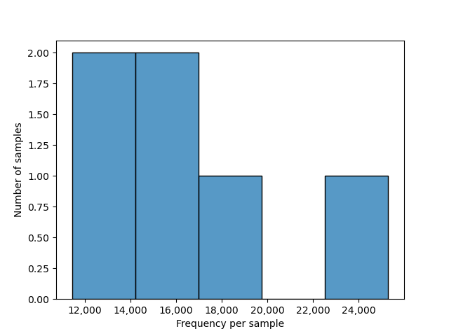

Sample read frequencies from the filtered feature table

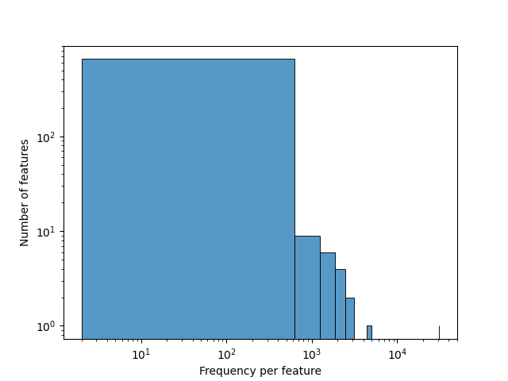

Feature (ASV) frequencies from the filtered feature table

### Taxonomic Barplot

After obtaining taxonomic identification for the sequences, QIIME provides a command to create an interactive visualization of the bacterial community using the generated taxonomy and table artifacts. This enables users to quickly grasp the initial findings of the bacterial community at a glance.

```bash
# Generate interactive taxonomy barplot visualization
qiime taxa barplot \
  --i-table output/qza/filtered_table.qza \
  --i-taxonomy output/qza/taxonomy.qza \
  --m-metadata-file metadata/metadata.tsv \
  --o-visualization output/qza/taxa-barplot.qzv
```

### Phylogenetic Tree

```bash
# Build phylogenetic tree: alignment -> masking -> unrooted tree -> rooted tree
qiime phylogeny align-to-tree-mafft-fasttree \
  --i-sequences ./output/qza/filtered_seqs.qza \
  --p-n-threads 10 \
  --output-dir ./output/qza/phylogeny-align-to-tree-mafft-fasttree

# Output directory contains:
#   alignment.qza         - MAFFT multiple sequence alignment
#   masked_alignment.qza  - alignment with highly variable positions masked
#   tree.qza              - unrooted FastTree phylogeny
#   rooted_tree.qza       - midpoint-rooted phylogeny (used in diversity analyses)
```

### Alpha Rarefaction

Before exporting, QIIME2 can generate an alpha-rarefaction curve to check whether the sequencing depth is sufficient to capture the diversity in each sample. The curve plots observed diversity against rarefaction depth; a plateau indicates adequate sampling. The result is a `.qzv` visualization that can be viewed at https://view.qiime2.org.

```bash
# Generate an interactive alpha-rarefaction curve to assess sampling depth
# Adjust --p-max-depth based on your sequencing depth (see filtered_table.qzv)
qiime diversity alpha-rarefaction \
  --i-table ./output/qza/filtered_table.qza \
  --m-metadata-file ./metadata/metadata.tsv \
  --p-min-depth 10 \
  --p-max-depth 48000 \
  --o-visualization ./output/qza/alpha-rarefaction-curves.qzv
```

### Export Files for Phyloseq

Following the creation of taxonomy, table, representative sequences, and tree artifacts, QIIME offers a command to export them directly into a tab-delimited text file. This is required for the subsequent downstream analysis that will be performed in R using the Phyloseq package. Additionally, a variable is placed to which it can identify the file names to be exported. The exported table is in BIOM format, so it requires to be converted into a tab-separated text file.

```bash
mkdir -p output/exports/table output/exports/filtered_table
mkdir -p output/exports/rep_seqs output/exports/filtered_seqs
mkdir -p output/exports/taxonomy output/exports/rooted_tree

# Export feature table (unfiltered)
qiime tools export \
  --input-path output/qza/table.qza \
  --output-path output/exports/table

# Export filtered feature table
qiime tools export \
  --input-path output/qza/filtered_table.qza \
  --output-path output/exports/filtered_table

# Export representative sequences
qiime tools export \
  --input-path output/qza/rep-seqs.qza \
  --output-path output/exports/rep_seqs

# Export filtered representative sequences
qiime tools export \
  --input-path output/qza/filtered_seqs.qza \
  --output-path output/exports/filtered_seqs

# Export taxonomy assignments
qiime tools export \
  --input-path output/qza/taxonomy.qza \
  --output-path output/exports/taxonomy

# Export rooted phylogenetic tree (required for UniFrac distances)
qiime tools export \
  --input-path ./output/qza/phylogeny-align-to-tree-mafft-fasttree/rooted_tree.qza \
  --output-path ./output/exports/rooted_tree

# Convert filtered feature table from BIOM to TSV format
biom convert \
  -i output/exports/filtered_table/feature-table.biom \
  -o output/exports/filtered_table/feature-table.tsv \
  --to-tsv

# Files used for Phyloseq import in R:
#   output/exports/filtered_table/feature-table.biom  - ASV counts
#   output/exports/taxonomy/taxonomy.tsv               - taxonomy assignments
#   output/exports/rooted_tree/tree.nwk                - phylogenetic tree
#   metadata/metadata.tsv                              - sample metadata
```

### Functional Predictions with PICRUSt2

Phylogenetic Investigation of Communities by Reconstruction of Unobserved States (PICRUSt2) is a software used to predict functional abundances based on the marker gene sequences of identified taxonomic samples. The term “function” refers to gene families like KEGG orthologs and Enzyme Classification numbers.

Using ASVs or OTUs, they are aligned with a reference tree using EPA-NG(v.03.8) and GAPPA (v.0.4.0) and gene family copy numbers are inferred. Once the gene family abundance is determined, pathway abundances are predicted.

PICRUSt2 is run as a single pipeline command using the exported filtered sequences (FASTA) and the filtered feature table (BIOM). Functional descriptions for KEGG Orthologs and MetaCyc pathways are added with `add_descriptions.py`.

```bash
#!/bin/bash

source ~/miniconda3/etc/profile.d/conda.sh
conda activate picrust2

# PICRUSt2 v2.6.2
# Inputs: filtered sequences FASTA and feature table BIOM

picrust2_pipeline.py \
    -s output/exports/filtered_seqs/dna-sequences.fasta \
    -i output/exports/filtered_table/feature-table.biom \
    -o picrust2_out \
    -p 20 \
    --in_traits EC,KO

# Add KEGG Ortholog descriptions
add_descriptions.py \
    -i picrust2_out/KO_metagenome_out/pred_metagenome_unstrat.tsv.gz \
    -m KO \
    -o picrust2_out/KO_metagenome_out/pred_metagenome_unstrat_descrip.tsv.gz

# Add MetaCyc pathway descriptions
add_descriptions.py \
    -i picrust2_out/pathways_out/path_abun_unstrat.tsv.gz \
    -m METACYC \
    -o picrust2_out/pathways_out/path_abun_unstrat_descrip.tsv.gz

# Outputs:
#   picrust2_out/KO_metagenome_out/pred_metagenome_unstrat.tsv.gz     - KO abundances
#   picrust2_out/KO_metagenome_out/pred_metagenome_unstrat_descrip.tsv.gz - KO with descriptions
#   picrust2_out/EC_metagenome_out/pred_metagenome_unstrat.tsv.gz     - EC abundances
#   picrust2_out/pathways_out/path_abun_unstrat.tsv.gz                - MetaCyc pathway abundances
#   picrust2_out/pathways_out/path_abun_unstrat_descrip.tsv.gz        - pathways with descriptions
```

# DOWNSTREAM ANALYSIS WITH R AND RSTUDIO

## Overview of R and RStudio

The R programming language is a powerful and open-source software environment primarily designed for statistical computing, data analysis, and graphical visualization. It offers a vast array of statistical and graphical techniques, making it popular among statisticians, data analysts, researchers, and professionals in various fields.

R Studio, on the other hand, is an integrated development environment (IDE) specifically tailored for working with R. It provides a user-friendly interface that streamlines the process of writing, executing, debugging, and visualizing R code.

## Installation and Setup

### Installing R

To install R, visit the official CRAN website at https://cran.rstudio.com and select the download link corresponding to your computer’s operating system (Windows, macOS, or Linux). Follow the installation prompts to complete the setup.

### Installing RStudio

To install RStudio, visit https://posit.co/download/rstudio-desktop and scroll down to find the installer that matches your operating system. Download the appropriate file and follow the installation prompts to complete the setup.

### Installing R Packages

To install the necessary R packages for microbiome analysis, click this Google Drive link: [RPackages](https://drive.google.com/drive/folders/1pQh0Eea1u8ldKyBdOfd0CfSFCE7J_D9G?usp=drive_link)

## Data Import and Preparation

### Importing QIIME2 Artifacts as a Phyloseq Object

Import the filtered feature table, taxonomy, rooted tree, and metadata produced by the QIIME2 pipeline directly into a single `phyloseq` object using the `qiime2R` package. This object is the foundation for every downstream analysis.

```r
# Install packages (run once)
# install.packages(c("vegan","ggplot2","dplyr","tidyr","ape",
#                    "data.table","scales","dunn.test","RColorBrewer"))
# BiocManager::install(c("phyloseq","microbiome","DESeq2","ComplexHeatmap"))
# remotes::install_github("jbisanz/qiime2R")
# remotes::install_github("pmartinezarbizu/pairwiseAdonis/pairwiseAdonis")
# remotes::install_github("gauravsk/ranacapa")

suppressPackageStartupMessages({
  library(phyloseq); library(qiime2R); library(microbiome); library(vegan)
  library(ggplot2);  library(dplyr);   library(tidyr);      library(ape)
  library(data.table); library(scales); library(dunn.test); library(DESeq2)
  library(picante);  library(tibble);  library(ranacapa)
  library(RColorBrewer); library(ComplexHeatmap)
})

# Project variables
features_qza <- "output/qza/filtered_table.qza"
taxonomy_qza <- "output/qza/taxonomy.qza"
tree_qza     <- "output/qza/phylogeny-align-to-tree-mafft-fasttree/rooted_tree.qza"
metadata_tsv <- "metadata/metadata.tsv"

group_var         <- "group1"
min_depth_filter  <- 1000
rarefaction_depth <- NULL      # NULL = auto-use minimum sample depth
min_taxa_presence <- 2

out_dir <- "output/r_analysis"
fig_dir <- file.path(out_dir, "figures")
tab_dir <- file.path(out_dir, "tables")
dir.create(fig_dir, recursive = TRUE, showWarnings = FALSE)
dir.create(tab_dir, recursive = TRUE, showWarnings = FALSE)

# Import QIIME2 artifacts directly into a phyloseq object
ps_raw <- qza_to_phyloseq(
  features = features_qza,
  taxonomy = taxonomy_qza,
  tree     = tree_qza,
  metadata = metadata_tsv
)
ps_raw
summary(sample_sums(ps_raw))
```

## Sequencing Depth and Rarefaction

### Sequencing Depth Per Sample

Inspect the number of reads retained per sample. Samples with very low depth are flagged for removal before diversity analysis.

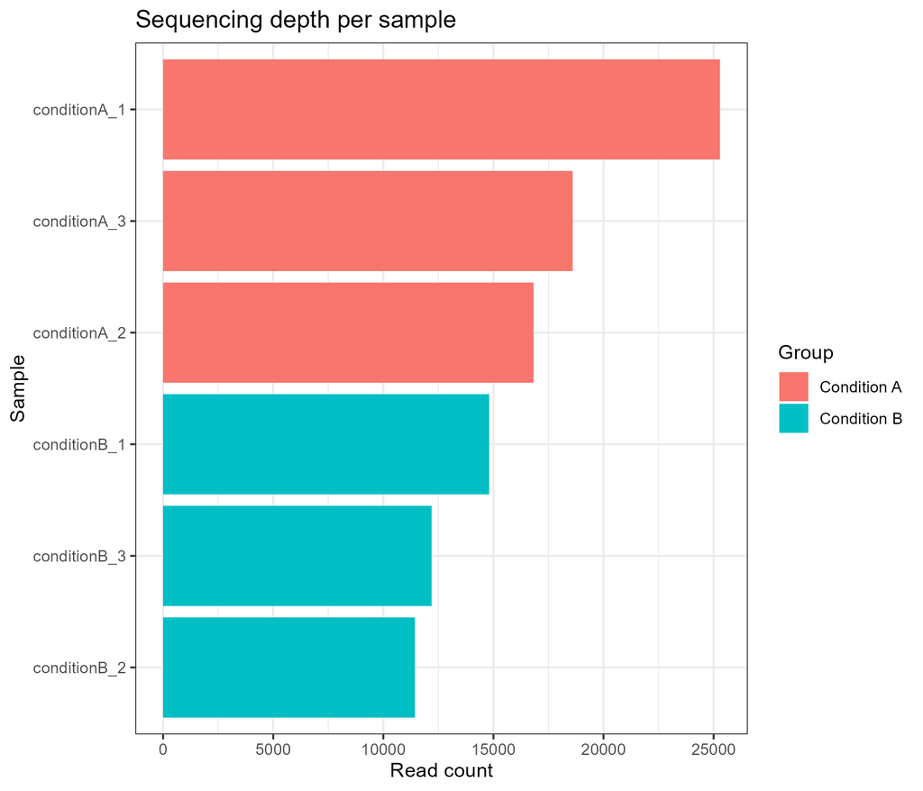

Sequencing depth per sample

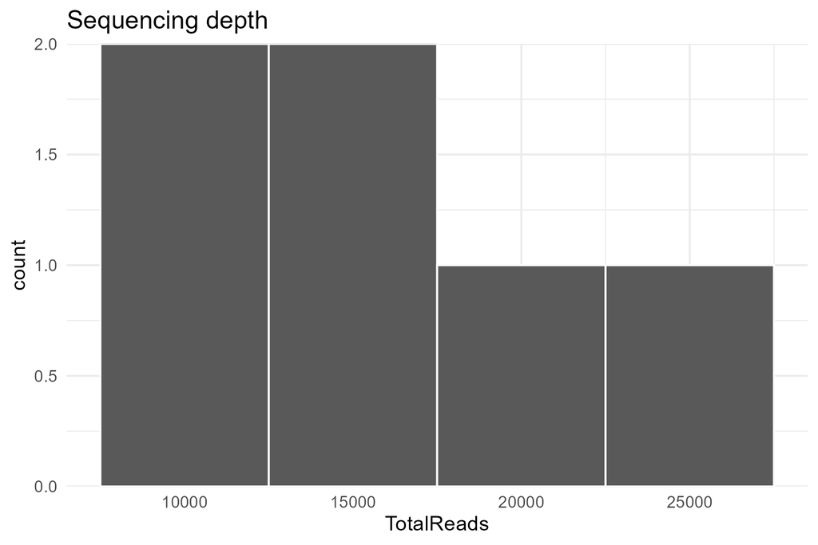

Histogram of sequencing depth

```r
# Sequencing depth per sample
depth_df <- data.frame(
  SampleID = sample_names(ps_raw),
  Depth    = sample_sums(ps_raw),
  Group    = sample_data(ps_raw)[[group_var]]
)
write.csv(depth_df, file.path(tab_dir, "sequencing_depth_per_sample.csv"), row.names = FALSE)

# Bar plot of depth per sample
p <- ggplot(depth_df, aes(x = reorder(SampleID, Depth), y = Depth, fill = Group)) +
  geom_col() + coord_flip() + theme_bw() +
  labs(x = "Sample", y = "Read count", title = "Sequencing depth per sample")
ggsave(file.path(fig_dir, "sequencing_depth_per_sample.png"), p, width = 7, height = 6, dpi = 300)

# Histogram of sequencing depth
readcount <- data.table(as(sample_data(ps_raw), "data.frame"),
                        TotalReads = sample_sums(ps_raw), keep.rownames = TRUE)
p <- ggplot(readcount, aes(TotalReads)) +
  geom_histogram(binwidth = 5000, color = "white") +
  scale_y_continuous(expand = c(0, 0)) + theme_minimal() +
  ggtitle("Sequencing depth")
ggsave(file.path(fig_dir, "sequencing_depth_histogram.png"), p, width = 6, height = 4, dpi = 300)
```

**Result table — sequencing depth per sample (sequencing_depth_per_sample.csv)**

| SampleID | Depth (reads) | Group |
| --- | --- | --- |
| conditionA_1 | 25289 | Condition A |
| conditionA_2 | 16825 | Condition A |
| conditionA_3 | 18603 | Condition A |
| conditionB_1 | 14817 | Condition B |
| conditionB_2 | 11437 | Condition B |
| conditionB_3 | 12202 | Condition B |

### Rarefaction

Generate a rarefaction curve to confirm that sequencing depth is sufficient, then rarefy all samples to an even depth so that diversity comparisons are not biased by library size.

```r
# Rarefaction curve
rarefaction_curve <- ggrare(ps_raw, step = 100, label = NULL, se = FALSE) +
  theme_bw() +
  scale_x_continuous(breaks = seq(0, max(sample_sums(ps_raw)), by = 2500)) +
  labs(title = "Alpha rarefaction curve")
rarefaction_curve

# Filter samples below the minimum depth, then rarefy to even depth
ps_depth_filtered <- prune_samples(sample_sums(ps_raw) >= min_depth_filter, ps_raw)
if (is.null(rarefaction_depth)) rarefaction_depth <- min(sample_sums(ps_depth_filtered))

set.seed(123)
ps_rarefied <- rarefy_even_depth(
  ps_depth_filtered, sample.size = rarefaction_depth,
  rngseed = 123, replace = FALSE, trimOTUs = TRUE, verbose = FALSE
)
ps_rarefied
```

## Taxonomy Cleaning and Filtering

### Filtering Taxonomies

Retain only bacterial taxa, remove chloroplast/mitochondria/NA assignments, and apply a prevalence filter that keeps taxa present in at least two samples. The unique taxa per rank are tabulated for reference.

```r
# Keep bacterial taxa; remove chloroplast, mitochondria and NA phyla
ps_clean <- subset_taxa(ps_rarefied, Kingdom == "d__Bacteria") %>%
  subset_taxa(!is.na(Phylum)) %>%
  subset_taxa(!Class  %in% c("Chloroplast")) %>%
  subset_taxa(!Family %in% c("mitochondria"))

# Prevalence filter: keep taxa present in >= min_taxa_presence samples
ps_clean_p0 <- filter_taxa(ps_clean,
  function(x) sum(x > 0) >= min_taxa_presence, prune = TRUE)
ps_clean_p0

# Count unique taxa per rank
taxa_count_by_rank <- tax_table(ps_clean_p0) %>%
  as("matrix") %>% as.data.frame() %>% rownames_to_column("ASV") %>%
  pivot_longer(cols = all_of(rank_names(ps_clean_p0)),
               names_to = "Rank", values_to = "Name") %>%
  filter(!is.na(Name), Name != "") %>%
  group_by(Rank) %>% summarize(n_taxa = length(unique(Name)), .groups = "drop")
write.csv(taxa_count_by_rank, file.path(tab_dir, "unique_taxa_by_rank.csv"), row.names = FALSE)
taxa_count_by_rank
```

**Result table — unique taxa per rank after filtering (unique_taxa_by_rank.csv)**

| Rank | Unique taxa |
| --- | --- |
| Kingdom | 1 |
| Phylum | 15 |
| Class | 19 |
| Order | 42 |
| Family | 70 |
| Genus | 112 |
| Species | 78 |

## Alpha Diversity

### Alpha Diversity Indices

Compute within-sample diversity using non-phylogenetic indices (Observed, Chao1, Shannon, Simpson, Fisher, ACE), Pielou evenness, and Faith phylogenetic diversity, then merge them with the sample metadata.

```r
ps_alpha <- ps_clean_p0

# Non-phylogenetic indices (phyloseq)
alpha_est <- estimate_richness(ps_alpha,
  measures = c("Observed","Chao1","Shannon","Simpson","Fisher","ACE")) %>%
  rownames_to_column("SampleID")

# Pielou evenness (microbiome)
alpha_micro <- microbiome::alpha(ps_alpha, index = c("pielou")) %>%
  as.data.frame() %>% rownames_to_column("SampleID")

# Faith phylogenetic diversity (picante)
faith_pd <- picante::pd(t(otu_table(ps_alpha)), phy_tree(ps_alpha), include.root = TRUE)
faith_pd <- data.frame(Faith_PD = faith_pd$PD, SampleID = rownames(faith_pd))

# Merge all metrics with metadata
alpha_all <- data.frame(sample_data(ps_alpha)) %>% rownames_to_column("SampleID") %>%
  left_join(alpha_est,   by = "SampleID") %>%
  left_join(alpha_micro, by = "SampleID") %>%
  left_join(faith_pd,    by = "SampleID")
write.csv(alpha_all, file.path(tab_dir, "alpha_diversity.csv"), row.names = FALSE)
alpha_all
```

**Result table — alpha diversity indices per sample (alpha_diversity.csv)**

| SampleID | Group | Observed | Chao1 | Shannon | Simpson | Pielou | Faith PD |
| --- | --- | --- | --- | --- | --- | --- | --- |
| conditionA_1 | Condition A | 96 | 96.4 | 2.73 | 0.841 | 0.598 | 7.41 |
| conditionA_2 | Condition A | 104 | 104 | 2.15 | 0.64 | 0.463 | 9.22 |
| conditionA_3 | Condition A | 87 | 87.6 | 1.79 | 0.563 | 0.401 | 7.63 |
| conditionB_1 | Condition B | 159 | 159 | 4.14 | 0.966 | 0.816 | 9.94 |
| conditionB_2 | Condition B | 154 | 154 | 3.95 | 0.957 | 0.784 | 10.4 |
| conditionB_3 | Condition B | 152 | 152 | 3.99 | 0.962 | 0.793 | 9.28 |

### Statistical Analysis

Test for differences in alpha diversity between groups using parametric (ANOVA, Tukey HSD, pairwise t-test) and non-parametric (Kruskal-Wallis, pairwise Wilcoxon, Dunn) approaches.

```r
alpha_metric <- "Shannon"

# Parametric: ANOVA + Tukey HSD + pairwise t-test
anova_alpha <- aov(as.formula(paste(alpha_metric, "~", group_var)), data = alpha_all)
summary(anova_alpha)
TukeyHSD(anova_alpha)
pairwise.t.test(alpha_all[[alpha_metric]], alpha_all[[group_var]], p.adjust.method = "BH")

# Non-parametric: Kruskal-Wallis + pairwise Wilcoxon + Dunn test
kruskal.test(as.formula(paste(alpha_metric, "~", group_var)), data = alpha_all)
pairwise.wilcox.test(alpha_all[[alpha_metric]], alpha_all[[group_var]], p.adjust.method = "BH")

dunn_result <- dunn.test::dunn.test(alpha_all[[alpha_metric]], alpha_all[[group_var]],
                                    method = "bh", list = TRUE)
alpha_dunn <- data.frame(metric = alpha_metric, comparison = dunn_result$comparisons,
                         z = dunn_result$Z, p_adjusted = dunn_result$P.adjusted)
write.csv(alpha_dunn, file.path(tab_dir, "alpha_dunn_tests.csv"), row.names = FALSE)
alpha_dunn
```

### Alpha Diversity Visualization

Visualize each alpha diversity index as a boxplot grouped by treatment.

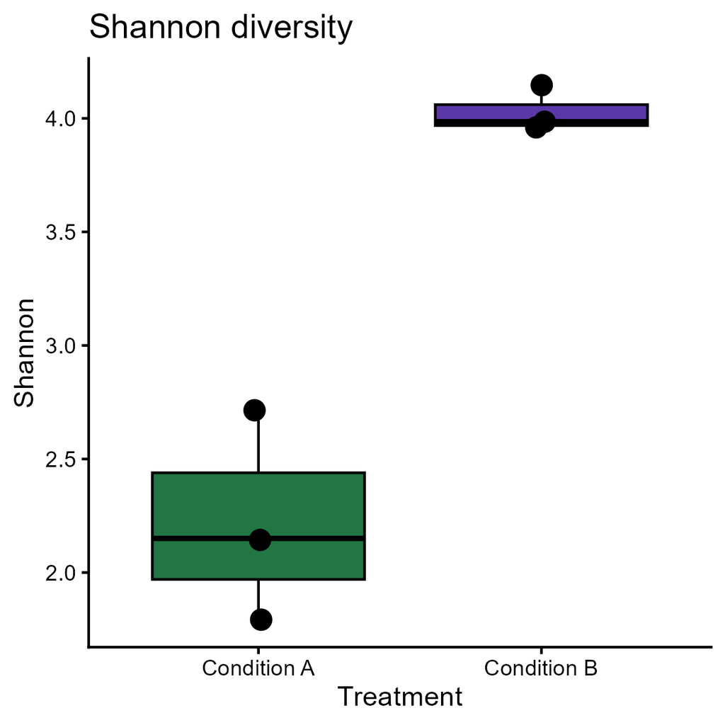

Shannon Diversity Index

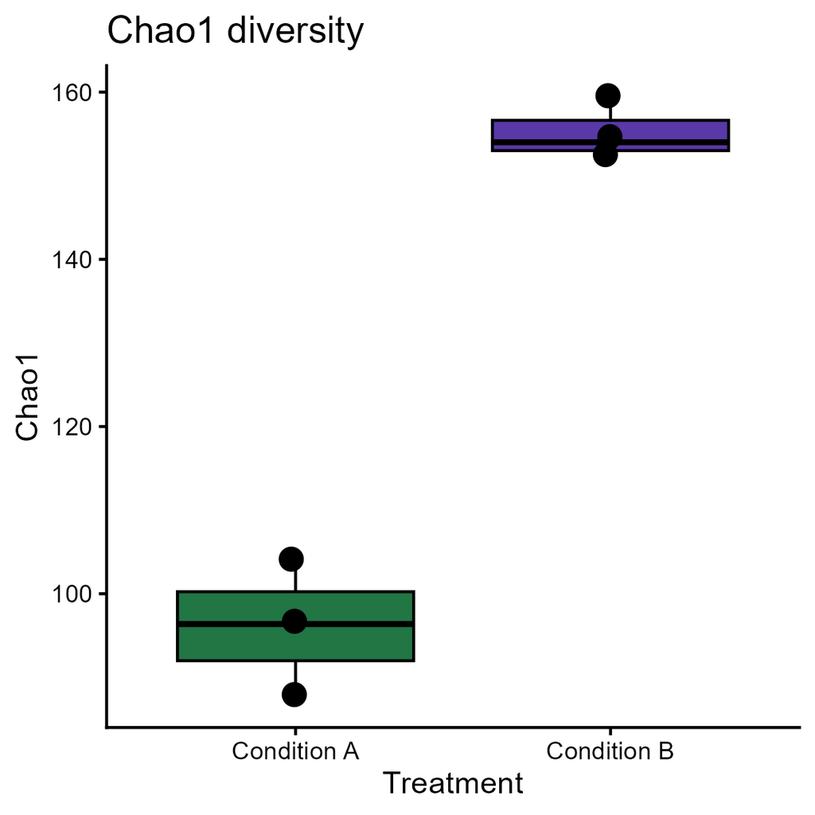

Chao1 Richness Estimator

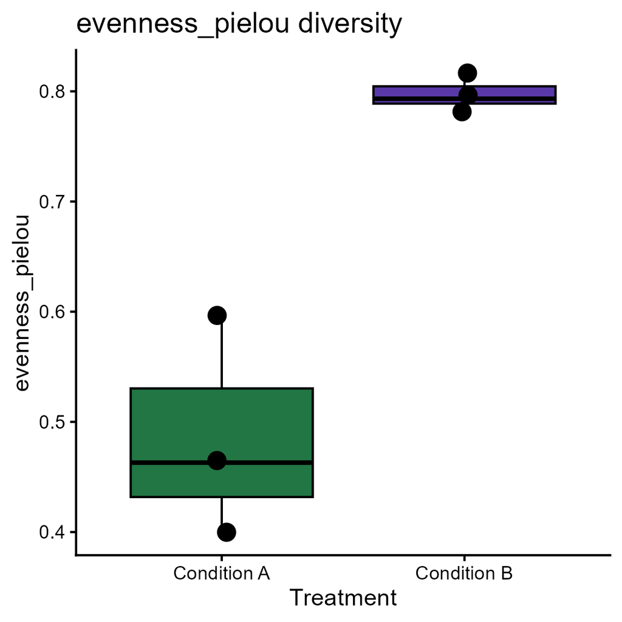

Pielou's Evenness

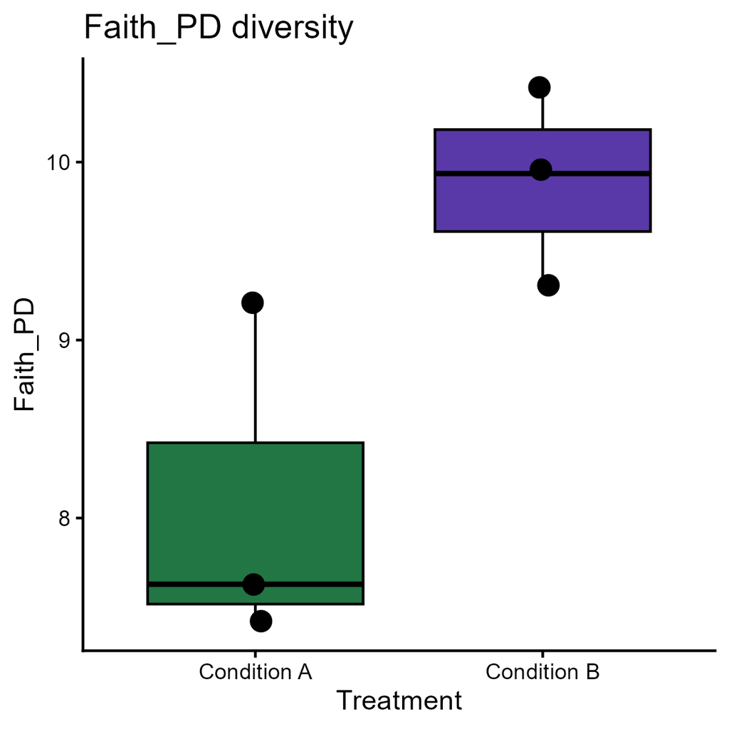

Faith's Phylogenetic Diversity

```r
# Alpha diversity boxplots: Shannon, Chao1, Pielou evenness, Faith PD
for (metric in c("Shannon", "Chao1", "evenness_pielou", "Faith_PD")) {
  p <- ggplot(alpha_all,
              aes(x = .data[[group_var]], y = .data[[metric]], fill = .data[[group_var]])) +
    geom_boxplot() + geom_jitter(width = 0.02, size = 3.5) +
    theme_classic() + scale_fill_manual(values = c("#217644", "#5938A8")) +
    labs(title = paste(metric, "diversity"), x = "Treatment", y = metric) +
    theme(legend.position = "none")
  print(p)
  ggsave(file.path(fig_dir, paste0("alpha_", tolower(metric), "_boxplot.png")),
         p, width = 4, height = 4, dpi = 300)
}
```

## Beta Diversity

### Distance / Dissimilarity Matrices

Compute four between-sample distance/dissimilarity matrices: Bray-Curtis, Jaccard, unweighted UniFrac, and weighted UniFrac.

```r
ps_beta <- ps_clean_p0

# Four distance/dissimilarity matrices
dist_bray     <- phyloseq::distance(ps_beta, method = "bray")
dist_jaccard  <- phyloseq::distance(ps_beta, method = "jaccard", binary = TRUE)
dist_unifrac  <- phyloseq::distance(ps_beta, method = "unifrac", weighted = FALSE)
dist_wunifrac <- phyloseq::distance(ps_beta, method = "unifrac", weighted = TRUE)
```

### Statistical Analysis

Assess group separation with multivariate dispersion (betadisper), PERMANOVA (adonis2), pairwise PERMANOVA, and ANOSIM, summarized across all four distance metrics.

```r
meta_df <- data.frame(sample_data(ps_beta))
group   <- meta_df[[group_var]]

# Dispersion (betadisper) + PERMANOVA (adonis2) + ANOSIM for Bray-Curtis
bd_bray <- betadisper(dist_bray, group); anova(bd_bray); permutest(bd_bray)
adonis2(dist_bray ~ group, data = meta_df, permutations = 999)
if (requireNamespace("pairwiseAdonis", quietly = TRUE))
  pairwiseAdonis::pairwise.adonis2(dist_bray ~ group, data = meta_df)
summary(anosim(dist_bray, grouping = group, permutations = 999))

# Summary across all four distances
beta_stats <- lapply(
  list(bray = dist_bray, jaccard = dist_jaccard,
       unweighted_unifrac = dist_unifrac, weighted_unifrac = dist_wunifrac),
  function(x) {
    disp <- betadisper(x, group)
    perm <- adonis2(x ~ group, permutations = 999)
    ano  <- anosim(x, grouping = group, permutations = 999)
    data.frame(dispersion_p = anova(disp)$`Pr(>F)`[1], permanova_r2 = perm$R2[1],
               permanova_p = perm$`Pr(>F)`[1], anosim_r = unname(ano$statistic),
               anosim_p = ano$signif)
  }) %>% bind_rows(.id = "distance")
write.csv(beta_stats, file.path(tab_dir, "beta_statistics.csv"), row.names = FALSE)
beta_stats
```

**Result table — beta diversity statistics across distance metrics (beta_statistics.csv)**

| Distance | Dispersion p | PERMANOVA R² | PERMANOVA p | ANOSIM R | ANOSIM p |
| --- | --- | --- | --- | --- | --- |
| bray | 0.603 | 0.855 | 0.1 | 1 | 0.1 |
| jaccard | 0.465 | 0.791 | 0.1 | 1 | 0.1 |
| unweighted_unifrac | 0.722 | 0.782 | 0.1 | 1 | 0.1 |
| weighted_unifrac | 0.327 | 0.894 | 0.1 | 1 | 0.1 |

*PERMANOVA (adonis2), multivariate dispersion (betadisper) and ANOSIM, 999 permutations.*

### Ordination (PCoA and NMDS)

Ordinate the samples with PCoA (Bray-Curtis and weighted UniFrac) and NMDS (Bray-Curtis) to visualize community structure.

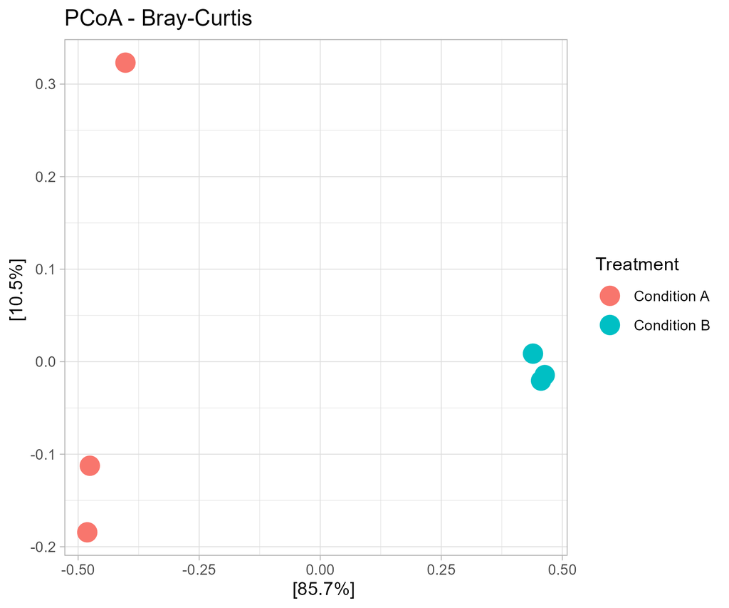

PCoA - Bray-Curtis

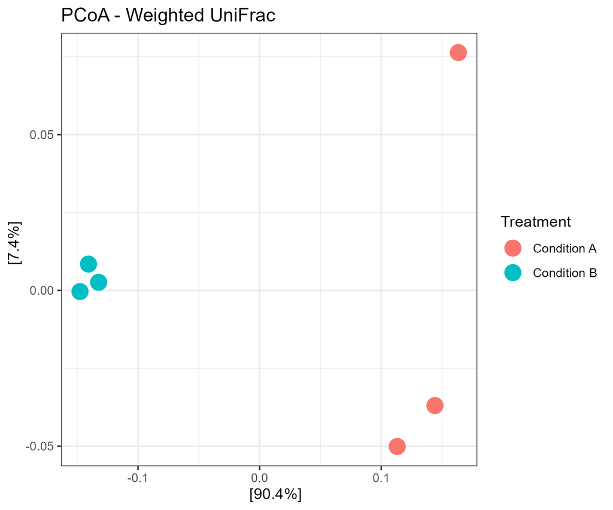

PCoA - Weighted UniFrac

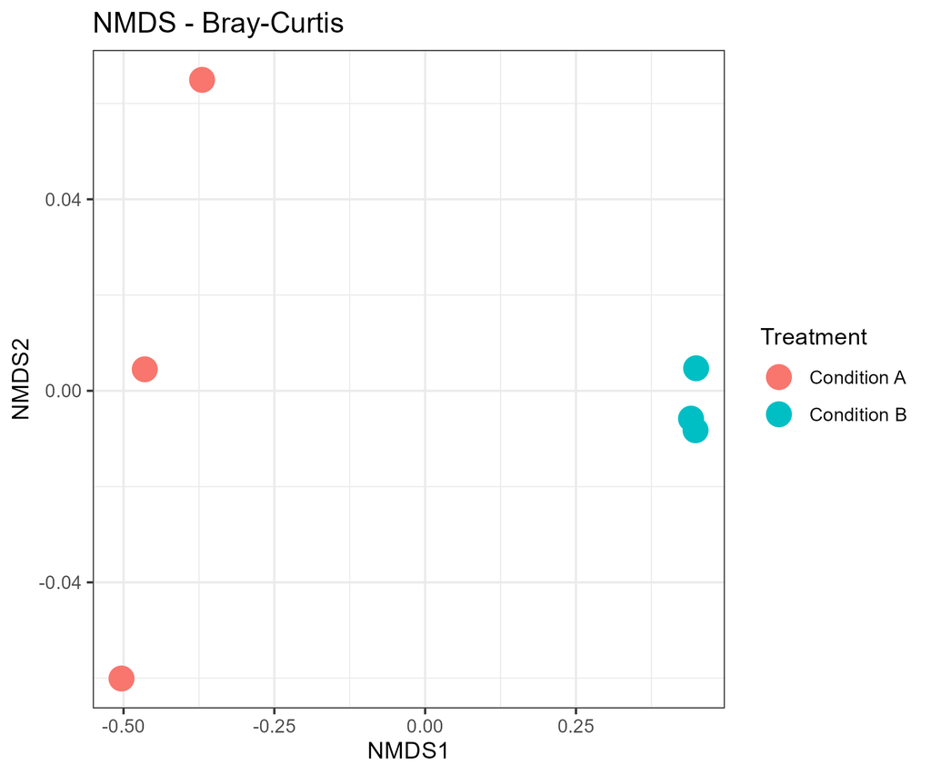

NMDS - Bray-Curtis

```r
# PCoA - Bray-Curtis
ord_pcoa_bray <- ordinate(ps_beta, method = "PCoA", distance = dist_bray)
p_pcoa_bray <- plot_ordination(ps_beta, ord_pcoa_bray, color = group_var) +
  geom_point(size = 5) + theme_light() +
  labs(title = "PCoA - Bray-Curtis", color = "Treatment")
ggsave(file.path(fig_dir, "pcoa_bray_curtis.png"), p_pcoa_bray, width = 6, height = 5, dpi = 300)

# PCoA - Weighted UniFrac
ord_pcoa_wu <- ordinate(ps_beta, method = "PCoA", distance = dist_wunifrac)
p_pcoa_wu <- plot_ordination(ps_beta, ord_pcoa_wu, color = group_var) +
  geom_point(size = 5) + theme_light() +
  labs(title = "PCoA - Weighted UniFrac", color = "Treatment")
ggsave(file.path(fig_dir, "pcoa_weighted_unifrac.png"), p_pcoa_wu, width = 6, height = 5, dpi = 300)

# NMDS - Bray-Curtis
ord_nmds_bray <- ordinate(ps_beta, method = "NMDS", distance = "bray", trymax = 100)
p_nmds_bray <- plot_ordination(ps_beta, ord_nmds_bray, color = group_var) +
  geom_point(size = 5) + theme_light() +
  labs(title = "NMDS - Bray-Curtis", color = "Treatment")
ggsave(file.path(fig_dir, "nmds_bray_curtis.png"), p_nmds_bray, width = 6, height = 5, dpi = 300)
```

## Taxonomic Composition

### Taxonomic Stacked Barplot

Plot relative abundance at the phylum level per sample and per group, and summarize the top 12 genera by treatment group.

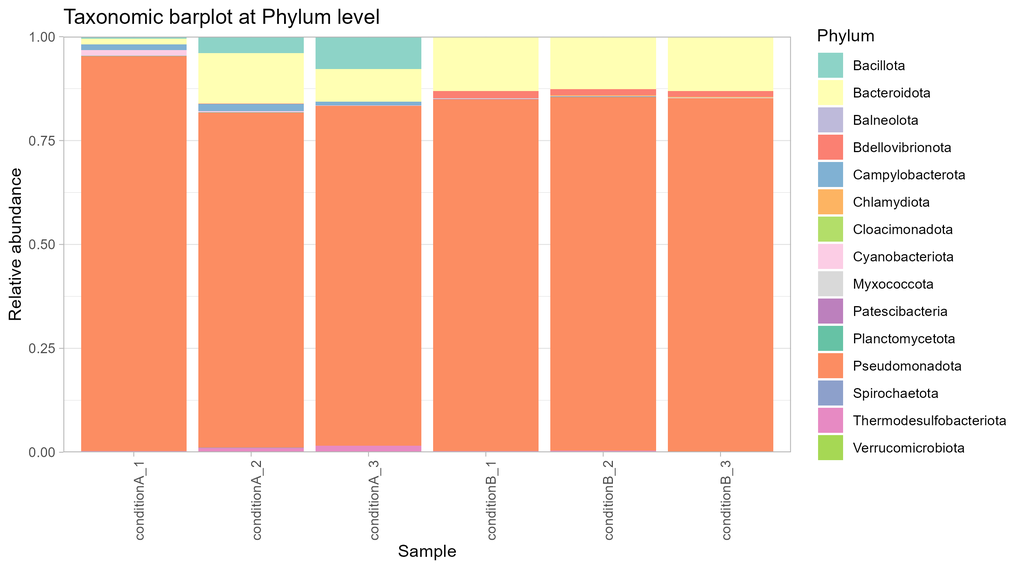

Relative abundance by sample (Phylum)

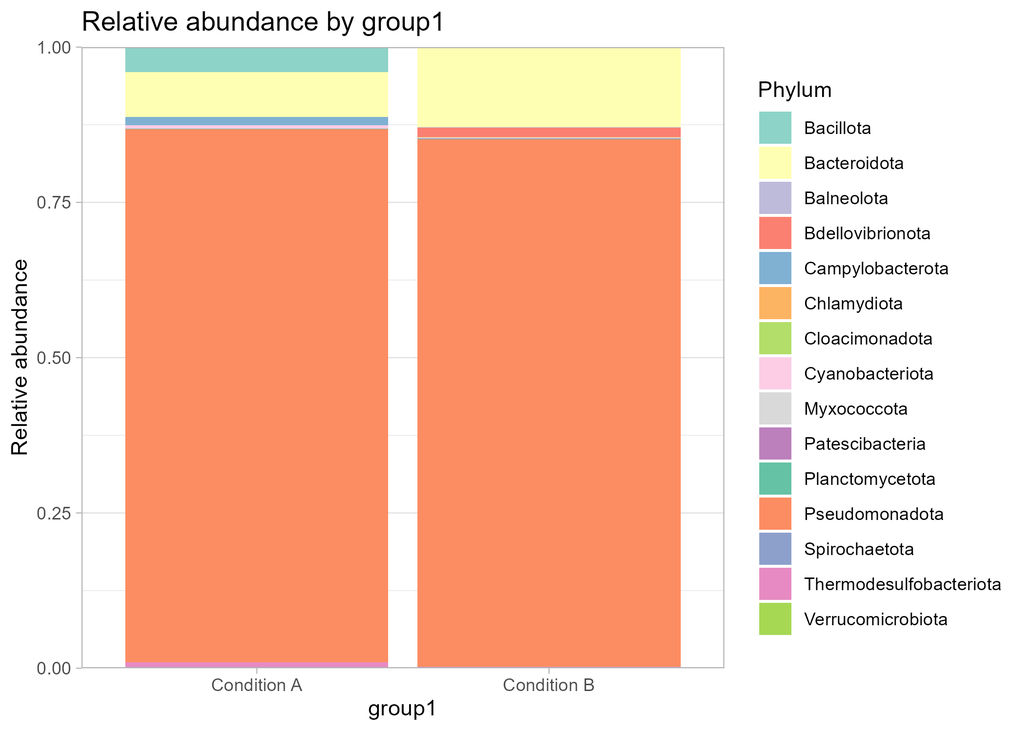

Relative abundance by group (Phylum)

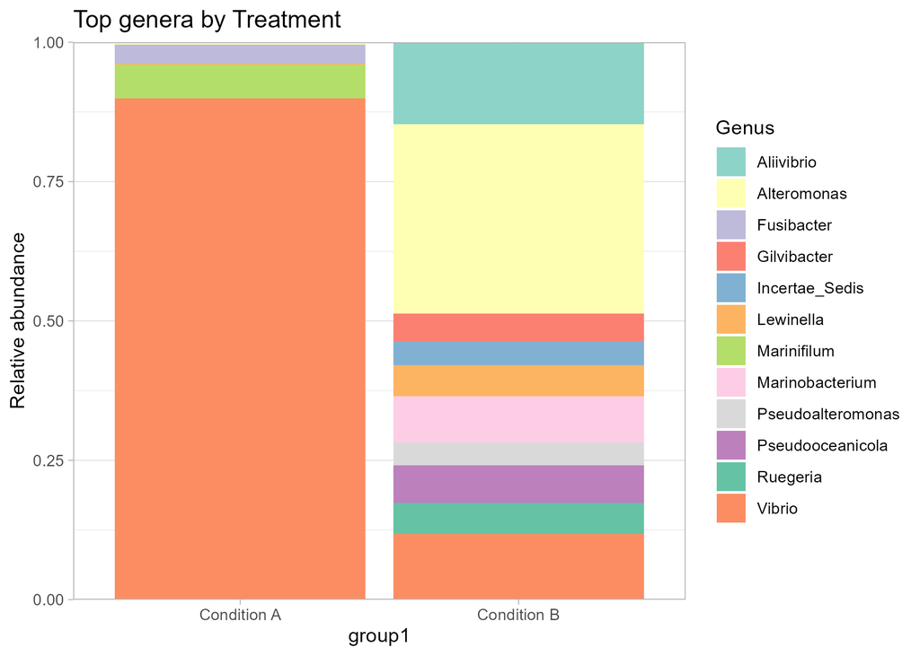

Top 12 genera by treatment group

```r
# Color palette for taxonomy plots
merged_color <- c(RColorBrewer::brewer.pal(10, "Set3"),
                  RColorBrewer::brewer.pal(8,  "Set2"))

# Agglomerate to phylum level and compute relative abundance
ps_tax     <- tax_glom(ps_clean_p0, taxrank = "Phylum", NArm = TRUE)
ps_tax_rel <- transform_sample_counts(ps_tax, function(x) x / sum(x))
tax_df     <- psmelt(ps_tax_rel)

# Per-sample barplot
p_tax_sample <- ggplot(tax_df, aes(x = Sample, y = Abundance, fill = Phylum)) +
  geom_bar(stat = "identity") + theme_light() +
  scale_fill_manual(values = merged_color) +
  theme(axis.text.x = element_text(angle = 90, hjust = 1)) +
  scale_y_continuous(expand = c(0, 0)) +
  labs(title = "Taxonomic barplot at Phylum level", x = "Sample", y = "Relative abundance")
ggsave(file.path(fig_dir, "taxonomic_barplot_sample_phylum.png"), p_tax_sample, width = 9, height = 5, dpi = 300)

# Per-group barplot
p_tax_group <- ggplot(tax_df, aes(x = .data[[group_var]], y = Abundance, fill = Phylum)) +
  geom_bar(stat = "identity", position = "fill") + theme_light() +
  scale_fill_manual(values = merged_color) + scale_y_continuous(expand = c(0, 0)) +
  labs(title = paste("Relative abundance by", group_var), x = group_var, y = "Relative abundance")
ggsave(file.path(fig_dir, "taxonomic_barplot_group_phylum.png"), p_tax_group, width = 7, height = 5, dpi = 300)

# Top 12 genera barplot
ps_top     <- tax_glom(ps_clean_p0, taxrank = "Genus", NArm = TRUE)
ps_top_rel <- transform_sample_counts(ps_top, function(x) x / sum(x))
top_taxa   <- names(sort(taxa_sums(ps_top_rel), decreasing = TRUE))[1:min(12, ntaxa(ps_top_rel))]
top_df     <- psmelt(prune_taxa(top_taxa, ps_top_rel)) %>%
  group_by(.data[[group_var]], Genus) %>%
  summarize(Abundance = mean(Abundance), .groups = "drop")
p_top <- ggplot(top_df, aes(x = .data[[group_var]], y = Abundance, fill = Genus)) +
  geom_col(position = "fill") + theme_light() +
  scale_fill_manual(values = merged_color) + scale_y_continuous(expand = c(0, 0)) +
  labs(title = "Top genera by Treatment", x = group_var, y = "Relative abundance")
ggsave(file.path(fig_dir, "top_genera_by_group.png"), p_top, width = 7, height = 5, dpi = 300)
```

## Heatmap

### Z-Score Heatmap of Top Genera

Build a Z-score normalized heatmap of the top 20 genera, clustered by both rows and columns.

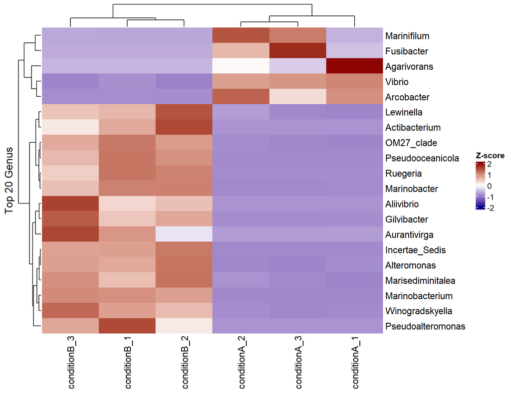

Z-score heatmap of the top 20 genera

```r
heat_tax_rank <- "Genus"; heat_top_n <- 20

ps_heat     <- tax_glom(ps_clean_p0, taxrank = heat_tax_rank, NArm = TRUE)
ps_heat_rel <- transform_sample_counts(ps_heat, function(x) x / sum(x) * 100)
top_taxa    <- names(sort(taxa_sums(ps_heat_rel), decreasing = TRUE))[1:min(heat_top_n, ntaxa(ps_heat_rel))]
ps_heat_top <- prune_taxa(top_taxa, ps_heat_rel)

otu_heat <- as.data.frame(otu_table(ps_heat_top))
if (!taxa_are_rows(ps_heat_top)) otu_heat <- t(otu_heat)
tax_heat <- as.data.frame(tax_table(ps_heat_top))
rownames(otu_heat) <- make.unique(as.character(tax_heat[[heat_tax_rank]]))

# Z-score scaling, capped at +/- 2
heat_z <- t(scale(t(as.matrix(otu_heat))))
heat_z[is.na(heat_z)] <- 0; heat_z[heat_z > 2] <- 2; heat_z[heat_z < -2] <- -2

col_fun <- circlize::colorRamp2(c(-2, 0, 2), c("darkblue", "white", "darkred"))
ht <- ComplexHeatmap::Heatmap(heat_z, name = "Z-score", col = col_fun,
  cluster_rows = TRUE, cluster_columns = TRUE,
  row_title = paste("Top", heat_top_n, heat_tax_rank))
png(file.path(fig_dir, "heatmap_zscore.png"), width = 1800, height = 1400, res = 200)
ComplexHeatmap::draw(ht); dev.off()
ht
```

## Differential Abundance Analysis

### DESeq2

Identify genera that differ significantly in abundance between the two treatment groups using DESeq2 on the non-rarefied counts, visualized as a volcano plot and a ranked bar chart of the top significant genera.

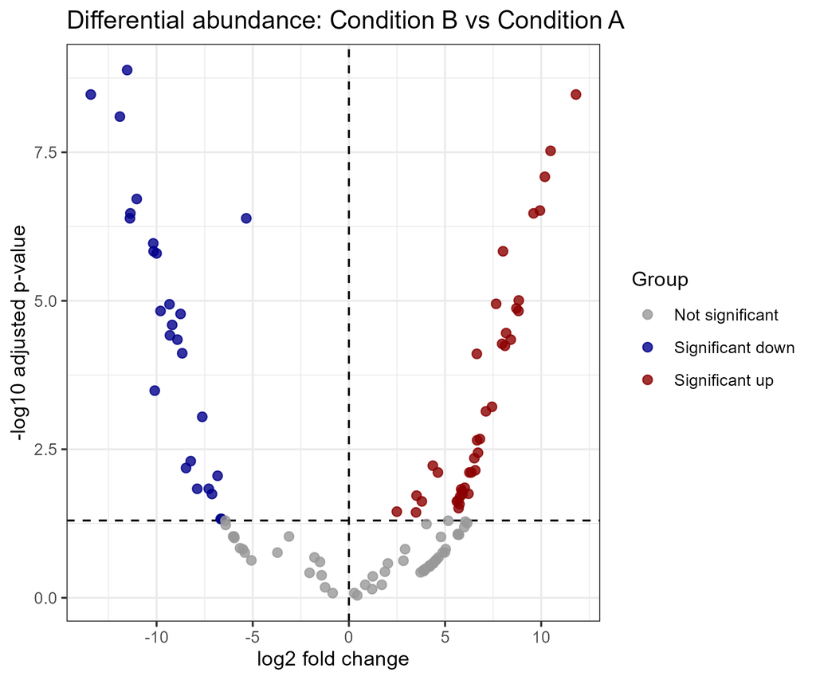

Volcano plot - DESeq2 genus-level results

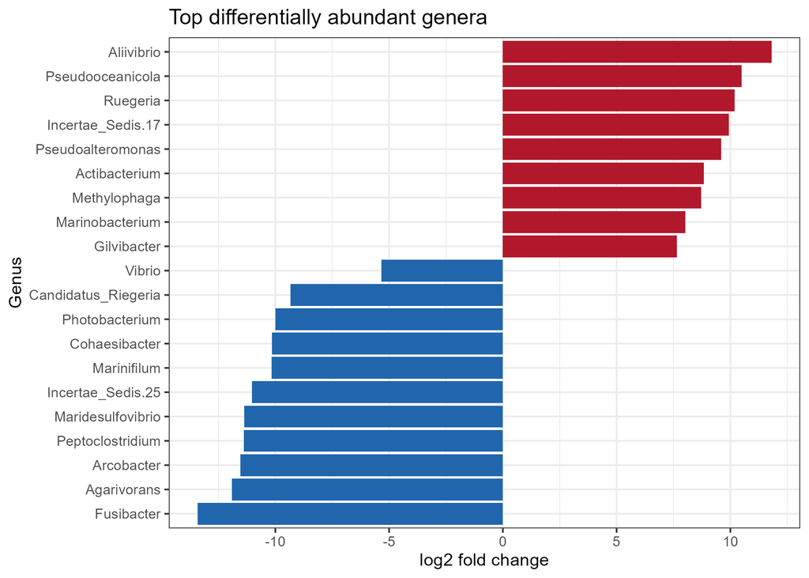

Top significant genera by log2 fold change

```r
# Prepare DESeq2 input from the non-rarefied data
ps_deseq <- prune_samples(sample_sums(ps_raw) >= min_depth_filter, ps_raw)
tax_deseq <- as.data.frame(tax_table(ps_deseq))
keep <- tax_deseq$Kingdom == "d__Bacteria" & !is.na(tax_deseq$Phylum) &
        !tax_deseq$Class %in% "Chloroplast" &
        !tax_deseq$Family %in% c("Mitochondria", "mitochondria")
ps_deseq <- prune_taxa(keep, ps_deseq)
ps_deseq <- filter_taxa(ps_deseq, function(x) sum(x > 0) >= min_taxa_presence, prune = TRUE)

# Agglomerate to genus and run DESeq2
sample_data(ps_deseq)[[group_var]] <- factor(sample_data(ps_deseq)[[group_var]])
ps_deseq_genus <- tax_glom(ps_deseq, taxrank = "Genus", NArm = TRUE)
taxa_names(ps_deseq_genus) <- make.unique(as.character(tax_table(ps_deseq_genus)[, "Genus"]))

dds <- phyloseq_to_deseq2(ps_deseq_genus, as.formula(paste("~", group_var)))
dds <- DESeq(dds, quiet = TRUE)
lv  <- levels(sample_data(ps_deseq_genus)[[group_var]])
da_df <- results(dds, contrast = c(group_var, lv[2], lv[1])) %>%
  as.data.frame() %>% rownames_to_column("Genus") %>% arrange(padj)
write.csv(da_df, file.path(tab_dir, "differential_abundance_deseq2_genus.csv"), row.names = FALSE)

# Volcano plot
da_df$diff_group <- "Not significant"
da_df$diff_group[da_df$padj < 0.05 & da_df$log2FoldChange < 0] <- "Significant down"
da_df$diff_group[da_df$padj < 0.05 & da_df$log2FoldChange > 0] <- "Significant up"
p_volcano <- ggplot(da_df, aes(log2FoldChange, -log10(padj))) +
  geom_hline(yintercept = -log10(0.05), linetype = "dashed") +
  geom_vline(xintercept = 0, linetype = "dashed") +
  geom_point(aes(color = diff_group), size = 2, alpha = 0.8) +
  scale_color_manual(values = c("Significant down" = "darkblue",
                                "Not significant"  = "grey60",
                                "Significant up"   = "darkred")) +
  theme_bw() + labs(title = paste("Differential abundance:", lv[2], "vs", lv[1]),
                    x = "log2 fold change", y = "-log10 adjusted p-value", color = "Group")
ggsave(file.path(fig_dir, "differential_abundance_volcano_genus.png"), p_volcano, width = 6, height = 5, dpi = 300)

# Top significant genera
top_da <- da_df %>% filter(!is.na(padj), padj < 0.05) %>% slice_min(padj, n = 20)
p_top <- ggplot(top_da, aes(reorder(Genus, log2FoldChange), log2FoldChange,
                            fill = log2FoldChange > 0)) +
  geom_col() + coord_flip() +
  scale_fill_manual(values = c("#2166ac", "#b2182b"), guide = "none") +
  theme_bw() + labs(title = "Top differentially abundant genera", x = "Genus", y = "log2 fold change")
ggsave(file.path(fig_dir, "differential_abundance_top_genera.png"), p_top, width = 7, height = 5, dpi = 300)

# Save final objects
saveRDS(ps_clean_p0, file.path(out_dir, "phyloseq_clean.rds"))
saveRDS(ps_deseq,    file.path(out_dir, "phyloseq_deseq_input.rds"))
```

**Result table — top 15 differentially abundant genera (differential_abundance_deseq2_genus.csv)**

| Genus | baseMean | log2FC | p-value | p-adj |
| --- | --- | --- | --- | --- |
| Arcobacter | 169 | -11.5 | 1.07e-11 | 1.31e-09 |
| Fusibacter | 625 | -13.4 | 6.75e-11 | 3.37e-09 |
| Aliivibrio | 461 | 11.8 | 8.28e-11 | 3.37e-09 |
| Agarivorans | 219 | -11.9 | 2.60e-10 | 7.93e-09 |
| Pseudooceanicola | 185 | 10.5 | 1.22e-09 | 2.99e-08 |
| Ruegeria | 150 | 10.2 | 4.02e-09 | 8.17e-08 |
| Incertae_Sedis.25 | 119 | -11 | 1.11e-08 | 1.93e-07 |
| Incertae_Sedis.17 | 126 | 9.93 | 1.99e-08 | 3.03e-07 |
| Maridesulfovibrio | 150 | -11.4 | 2.60e-08 | 3.37e-07 |
| Pseudoalteromonas | 100 | 9.6 | 2.76e-08 | 3.37e-07 |
| Peptoclostridium | 153 | -11.4 | 4.02e-08 | 4.09e-07 |
| Vibrio | 1.27e+04 | -5.34 | 3.85e-08 | 4.09e-07 |
| Marinifilum | 884 | -10.2 | 1.15e-07 | 1.08e-06 |
| Cohaesibacter | 65.1 | -10.2 | 1.75e-07 | 1.47e-06 |
| Marinobacterium | 237 | 8.01 | 1.80e-07 | 1.47e-06 |

*Full table contains 138 genera; sorted by adjusted p-value. Negative log2FC = enriched in the reference group.*

## Functional Predictions

### Loading PICRUSt2 Output

Load the PICRUSt2 KO abundance table and convert it to KEGG pathway abundances with `ggpicrust2`, then attach the sample metadata.

```r
# install.packages("ggpicrust2")
suppressPackageStartupMessages({
  library(ggpicrust2); library(ggplot2); library(dplyr); library(readr); library(tibble)
})

kegg_input_file <- "picrust2_out/KO_metagenome_out/pred_metagenome_unstrat.tsv.gz"
metadata_file   <- "metadata/metadata.tsv"
group_var       <- "group1"
out_dir         <- "output/picrust2_r_analysis"
fig_dir         <- file.path(out_dir, "figures")
dir.create(fig_dir, recursive = TRUE, showWarnings = FALSE)

# Convert KO abundances to KEGG pathway abundances
kegg_abundance <- ko2kegg_abundance(kegg_input_file)

# Load metadata (drop the #q2:types row)
metadata_func <- readr::read_delim(metadata_file, delim = "\t",
  escape_double = FALSE, trim_ws = TRUE, show_col_types = FALSE)
if (metadata_func[1, 1] == "#q2:types") metadata_func <- metadata_func[-1, , drop = FALSE]
metadata_func <- metadata_func %>% rename(SampleID = 1)
```

### Differential Abundance of KEGG Pathways

Run pathway differential abundance analysis with ALDEx2, DESeq2, and edgeR, compare the methods, and plot the top 30 pathways as an error-bar plot plus a pathway PCA.

```r
# Differential abundance with three methods, then compare
methods <- c("ALDEx2", "DESeq2", "edgeR")
daa_results_list <- lapply(methods, function(m)
  pathway_daa(abundance = kegg_abundance, metadata = metadata_func,
              group = group_var, daa_method = m))
names(daa_results_list) <- methods
comparison_results <- compare_daa_results(daa_results_list,
  method_names = c("ALDEx2_Welch_t_test", "DESeq2", "edgeR"))
write.csv(comparison_results, file.path(out_dir, "pathway_daa_method_comparison.csv"), row.names = FALSE)

# Annotate KO results with KEGG pathway names
for (i in seq_along(methods)) {
  daa_annotated <- pathway_annotation(pathway = "KO",
    daa_results_df = daa_results_list[[i]], ko_to_kegg = TRUE)
  write.table(daa_annotated, file.path(out_dir, paste0("KO_sig_", methods[i], ".txt")),
              sep = "\t", row.names = FALSE, quote = FALSE)
}

# Top 30 pathways error-bar plot (DESeq2 result)
KO_sig <- read.table(file.path(out_dir, "KO_sig_DESeq2.txt"), sep = "\t", header = TRUE)
Group  <- metadata_func[[group_var]]
top_pathways <- KO_sig %>% arrange(p_adjust) %>% slice_head(n = 30) %>% pull(feature)
pathway_errorbar(abundance = kegg_abundance, daa_results_df = KO_sig, Group = Group,
  p_values_threshold = 0.05, select = top_pathways, ko_to_kegg = TRUE,
  order = "group", p_value_bar = TRUE, x_lab = "pathway_map")
ggsave(file.path(fig_dir, "kegg_pathway_errorbar_top30.png"), width = 9, height = 7, dpi = 300)

# Pathway PCA
pathway_pca(abundance = kegg_abundance, metadata = metadata_func, group = group_var)
ggsave(file.path(fig_dir, "kegg_pathway_pca.png"), width = 6, height = 5, dpi = 300)
```

[output not shown]

### Pathway Heatmap (MetaCyc)

Visualize MetaCyc pathway abundances across groups as a heatmap.

```r
# MetaCyc pathway heatmap (with pathway descriptions added by add_descriptions.py)
metacyc_file <- "picrust2_out/pathways_out/path_abun_unstrat_descrip.tsv.gz"
metacyc_abundance <- read.table(gzfile(metacyc_file), sep = "\t",
  header = TRUE, row.names = 1, check.names = FALSE)

pathway_heatmap(abundance = metacyc_abundance, metadata = metadata_func,
                group = group_var, ko_to_kegg = FALSE)
ggsave(file.path(fig_dir, "metacyc_pathway_heatmap.png"), width = 10, height = 8, dpi = 300)
```

[output not shown]

# REFERENCES

The following tools and resources are referenced in this training module:

1. **FastQC** - Andrews, S. (2010). FastQC: A Quality Control Tool for High Throughput Sequence Data. https://www.bioinformatics.babraham.ac.uk/projects/fastqc/
2. **PERMANOVA** - Anderson, M. J. (2001). A new method for non-parametric multivariate analysis of variance. *Austral Ecology*, 26(1), 32-46.
3. **qiime2R** - Bisanz, J. E. (2018). qiime2R: Importing QIIME2 artifacts and associated data into R sessions. https://github.com/jbisanz/qiime2R
4. **QIIME2** - Bolyen, E., Rideout, J. R., Dillon, M. R., Bokulich, N. A., Abnet, C. C., Al-Ghalith, G. A., ... & Caporaso, J. G. (2019). Reproducible, interactive, scalable and extensible microbiome data science using QIIME 2. *Nature Biotechnology*, 37(8), 852-857. https://doi.org/10.1038/s41587-019-0209-9
5. **DADA2** - Callahan, B. J., McMurdie, P. J., Rosen, M. J., Han, A. W., Johnson, A. J. A., & Holmes, S. P. (2016). DADA2: High-resolution sample inference from Illumina amplicon data. *Nature Methods*, 13(7), 581-583. https://doi.org/10.1038/nmeth.3869
6. **microbiomeMarker** - Cao, Y. (2022). microbiomeMarker: microbiome biomarker analysis toolkit. R package. https://github.com/yiluheihei/microbiomeMarker
7. **ggpicrust2** - Chen, C. (2023). ggpicrust2: Make PICRUSt2 Output Analysis and Visualization Easier. R package. https://github.com/cafferychen777/ggpicrust2
8. **GUniFrac** - Chen, J., Bittinger, K., Charlson, E. S., Hoffmann, C., Lewis, J., Wu, G. D., ... & Li, H. (2012). Associating microbiome composition with environmental covariates using generalized UniFrac distances. *Bioinformatics*, 28(16), 2106-2113.
9. **PICRUSt2** - Douglas, G. M., Maffei, V. J., Zaneveld, J. R., Yurgel, S. N., Brown, J. R., Taylor, C. M., ... & Langille, M. G. (2020). PICRUSt2 for prediction of metagenome functions. *Nature Biotechnology*, 38(6), 685-688. https://doi.org/10.1038/s41587-020-0548-6
10. **Dunn Test** - Dunn, O. J. (1964). Multiple comparisons using rank sums. *Technometrics*, 6(3), 241-252.
11. **Kruskal-Wallis Test** - Kruskal, W. H., & Wallis, W. A. (1952). Use of ranks in one-criterion variance analysis. *Journal of the American Statistical Association*, 47(260), 583-621.
12. **microbiome** - Lahti, L., & Shetty, S. (2017). microbiome R package. http://microbiome.github.io
13. **ANCOM-BC** - Lin, H., & Peddada, S. D. (2020). Analysis of compositions of microbiomes with bias correction. *Nature Communications*, 11(1), 3514. https://doi.org/10.1038/s41467-020-17041-7
14. **Cutadapt** - Martin, M. (2011). Cutadapt removes adapter sequences from high-throughput sequencing reads. *EMBnet.journal*, 17(1), 10-12. https://doi.org/10.14806/ej.17.1.200
15. **phyloseq** - McMurdie, P. J., & Holmes, S. (2013). phyloseq: an R package for reproducible interactive analysis and graphics of microbiome census data. *PLoS ONE*, 8(4), e61217. https://doi.org/10.1371/journal.pone.0061217
16. **vegan** - Oksanen, J., Simpson, G. L., Blanchet, F. G., Kindt, R., Legendre, P., Minchin, P. R., ... & Wagner, H. (2022). vegan: Community Ecology Package. R package version 2.6-4. https://CRAN.R-project.org/package=vegan
17. **zCompositions** - Palarea-Albaladejo, J., & Martín-Fernández, J. A. (2015). zCompositions — R package for multivariate imputation of left-censored data under a compositional approach. *Chemometrics and Intelligent Laboratory Systems*, 143, 85-96.
18. **SILVA Database** - Quast, C., Pruesse, E., Yilmaz, P., Gerken, J., Schweer, T., Yarza, P., ... & Glöckner, F. O. (2012). The SILVA ribosomal RNA gene database project: improved data processing and web-based tools. *Nucleic Acids Research*, 41(D1), D590-D596. https://doi.org/10.1093/nar/gks1219
19. **R** - R Core Team (2023). R: A Language and Environment for Statistical Computing. R Foundation for Statistical Computing, Vienna, Austria. https://www.R-project.org/
20. **phytools** - Revell, L. J. (2012). phytools: an R package for phylogenetic comparative biology (and other things). *Methods in Ecology and Evolution*, 3(2), 217-223.
21. **RStudio** - RStudio Team (2023). RStudio: Integrated Development Environment for R. Posit Software, PBC, Boston, MA. http://www.rstudio.com/
22. **LEfSe** - Segata, N., Izard, J., Waldron, L., Gevers, D., Miropolsky, L., Garrett, W. S., & Huttenhower, C. (2011). Metagenomic biomarker discovery and explanation. *Genome Biology*, 12(6), R60. https://doi.org/10.1186/gb-2011-12-6-r60
23. **ggplot2** - Wickham, H. (2016). ggplot2: Elegant Graphics for Data Analysis. Springer-Verlag New York. https://ggplot2.tidyverse.org
24. **dplyr** - Wickham, H., François, R., Henry, L., & Müller, K. (2023). dplyr: A Grammar of Data Manipulation. R package. https://CRAN.R-project.org/package=dplyr
25. **DECIPHER** - Wright, E. S. (2016). Using DECIPHER v2.0 to Analyze Big Biological Sequence Data in R. *The R Journal*, 8(1), 352-359.
26. **MicrobiotaProcess** - Xu, S., Zhan, L., Tang, W., Wang, Q., Dai, Z., Zhou, L., ... & Yu, G. (2023). MicrobiotaProcess: A comprehensive R package for deep mining microbiome. *The Innovation*, 4(2), 100388. https://doi.org/10.1016/j.xinn.2023.100388